# Introduction

In this project, you will build a neural network of your own design to evaluate the MNIST dataset.

Some of the benchmark results on MNIST include can be found [on Yann LeCun's page](http://yann.lecun.com/exdb/mnist/) and include:

88% [Lecun et al., 1998](http://yann.lecun.com/exdb/publis/pdf/lecun-98.pdf) 95.3% [Lecun et al., 1998](http://yann.lecun.com/exdb/publis/pdf/lecun-98.pdf) 99.65% [Ciresan et al., 2011](http://people.idsia.ch/~juergen/ijcai2011.pdf)

MNIST is a great dataset for sanity checking your models, since the accuracy levels achieved by large convolutional neural networks and small linear models are both quite high. This makes it important to be familiar with the data.

## Imports

```python
## This cell contains the essential imports you will need – DO NOT CHANGE THE CONTENTS! ##
import torch
import torch.nn as nn
import torch.nn.functional as F
import torch.optim as optim
import torchvision
import torchvision.transforms as transforms
import matplotlib.pyplot as plt
import numpy as np
```

## Load the Dataset

MNIST is fortunately included in the torchvision module. Then, you can create your dataset using the `MNIST` object from `torchvision.datasets` ([the documentation is available here](https://pytorch.org/vision/stable/datasets.html#mnist)). Make sure to specify `download=True`!

Once your dataset is created, you'll also need to define a `DataLoader` from the `torch.utils.data` module for both the train and the test set.

```python
from torch.utils.data import DataLoader
# Define transforms
transform = transforms.Compose([
    transforms.ToTensor()])
# Create training set and define training dataloader
train_set = torchvision.datasets.MNIST(root='data', train=True, download=True, transform=transform)
train_loader = DataLoader(train_set, batch_size=64, shuffle=True)

# Create test set and define test dataloader
test_set = torchvision.datasets.MNIST(root='data', train=False, download=True, transform=transform)
test_loader = DataLoader(test_set, batch_size=64, shuffle=False)
```

## Justify your preprocessing

In your own words, why did you choose the transforms you chose? If you didn't use any preprocessing steps, why not?

## Explore the Dataset

Using matplotlib, numpy, and torch, explore the dimensions of your data.

You can view images using the `show5` function defined below – it takes a data loader as an argument. Remember that normalized images will look really weird to you! You may want to try changing your transforms to view images. Typically using no transforms other than `toTensor()` works well for viewing – but not as well for training your network. If `show5` doesn't work, go back and check your code for creating your data loaders and your training/test sets.

```python
## This cell contains a function for showing 5 images from a dataloader – DO NOT CHANGE THE CONTENTS! ##
def show5(img_loader):
    dataiter = iter(img_loader)

    batch = next(dataiter)
    labels = batch[1][0:5]
    images = batch[0][0:5]
    for i in range(5):
        print(int(labels[i].detach()))

        image = images[i].numpy()
        plt.imshow(image.T.squeeze().T)
        plt.show()
```

```
Training data size: 60000
Test data size: 10000
Shape of training data: torch.Size([1, 28, 28])
Shape of test data: torch.Size([1, 28, 28])
5
```

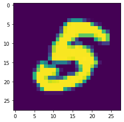

```
9
```

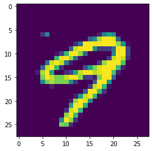

```
2
```

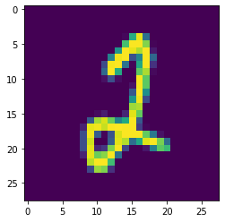

```
9
```

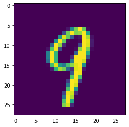

```
7
```

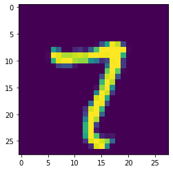

```python
# Explore data
print("Training data size:", len(train_set))
print("Test data size:", len(test_set))
print("Shape of training data:", train_set[0][0].shape)
print("Shape of test data:", test_set[0][0].shape)
show5(train_loader)
```

## Build your Neural Network

Using the layers in `torch.nn` (which has been imported as `nn`) and the `torch.nn.functional` module (imported as `F`), construct a neural network based on the parameters of the dataset. Use any architecture you like.

*Note*: If you did not flatten your tensors in your transforms or as part of your preprocessing and you are using only `Linear` layers, make sure to use the `Flatten` layer in your network!

```python
class NeuralNetwork(nn.Module):
    def __init__(self):
        super(NeuralNetwork, self).__init__()
        self.flatten = nn.Flatten()
        self.fc1 = nn.Linear(784, 128)
        self.fc2 = nn.Linear(128, 64)
        self.fc3 = nn.Linear(64, 10)

    def forward(self, x):
        x = self.flatten(x)
        x = F.relu(self.fc1(x))
        x = F.relu(self.fc2(x))
        x = self.fc3(x)
        return x
```

Specify a loss function and an optimizer, and instantiate the model.

If you use a less common loss function, please note why you chose that loss function in a comment.

```python
model = NeuralNetwork()

# loss function
criterion = nn.CrossEntropyLoss()

# optimizer
optimizer = optim.SGD(model.parameters(), lr=0.001, momentum=0.9)
```

## Running your Neural Network

Use whatever method you like to train your neural network, and ensure you record the average loss at each epoch. Don't forget to use `torch.device()` and the `.to()` method for both your model and your data if you are using GPU!

If you want to print your loss **during** each epoch, you can use the `enumerate` function and print the loss after a set number of batches. 250 batches works well for most people!

```python
device = torch.device("cuda" if torch.cuda.is_available() else "cpu")
model.to(device)

# Set the model to training mode
model.train()

# Define the number of batches to print the loss
print_loss_every = 250

# Lists to store the loss values
train_loss_values = []


num_epochs = 20  # Define the number of epochs

# Training loop
for epoch in range(num_epochs):
    running_loss = 0.0

    for batch_idx, (images, labels) in enumerate(train_loader):
        # Move the data to the appropriate device
        images = images.to(device)
        labels = labels.to(device)

        # Zero the gradients
        optimizer.zero_grad()

        # Forward pass
        outputs = model(images)
        loss = criterion(outputs, labels)

        # Backward pass and optimization
        loss.backward()
        optimizer.step()

        # Record the loss
        running_loss += loss.item()

        # Print the loss every few batches
        if (batch_idx + 1) % print_loss_every == 0:
            avg_loss = running_loss / print_loss_every
            print(f"Epoch [{epoch+1}/{num_epochs}], Batch [{batch_idx+1}/{len(train_loader)}], Loss: {avg_loss:.4f}")
            train_loss_values.append(avg_loss)
            running_loss = 0.0
```

```
Epoch [1/20], Batch [250/938], Loss: 2.2579
Epoch [1/20], Batch [500/938], Loss: 2.0256
Epoch [1/20], Batch [750/938], Loss: 1.4286
Epoch [2/20], Batch [250/938], Loss: 0.6983
Epoch [2/20], Batch [500/938], Loss: 0.5649
Epoch [2/20], Batch [750/938], Loss: 0.4948
Epoch [3/20], Batch [250/938], Loss: 0.4251
Epoch [3/20], Batch [500/938], Loss: 0.4005
Epoch [3/20], Batch [750/938], Loss: 0.3663
Epoch [4/20], Batch [250/938], Loss: 0.3534
Epoch [4/20], Batch [500/938], Loss: 0.3370
Epoch [4/20], Batch [750/938], Loss: 0.3361
Epoch [5/20], Batch [250/938], Loss: 0.3085
Epoch [5/20], Batch [500/938], Loss: 0.3131
Epoch [5/20], Batch [750/938], Loss: 0.3022
Epoch [6/20], Batch [250/938], Loss: 0.2894
Epoch [6/20], Batch [500/938], Loss: 0.2739
Epoch [6/20], Batch [750/938], Loss: 0.2887
Epoch [7/20], Batch [250/938], Loss: 0.2729
Epoch [7/20], Batch [500/938], Loss: 0.2646
Epoch [7/20], Batch [750/938], Loss: 0.2657
Epoch [8/20], Batch [250/938], Loss: 0.2549
Epoch [8/20], Batch [500/938], Loss: 0.2496
Epoch [8/20], Batch [750/938], Loss: 0.2466
Epoch [9/20], Batch [250/938], Loss: 0.2332
Epoch [9/20], Batch [500/938], Loss: 0.2373
Epoch [9/20], Batch [750/938], Loss: 0.2347
Epoch [10/20], Batch [250/938], Loss: 0.2176
Epoch [10/20], Batch [500/938], Loss: 0.2194
Epoch [10/20], Batch [750/938], Loss: 0.2269
Epoch [11/20], Batch [250/938], Loss: 0.2106
Epoch [11/20], Batch [500/938], Loss: 0.2132
Epoch [11/20], Batch [750/938], Loss: 0.2135
Epoch [12/20], Batch [250/938], Loss: 0.2070
Epoch [12/20], Batch [500/938], Loss: 0.1977
Epoch [12/20], Batch [750/938], Loss: 0.1870
Epoch [13/20], Batch [250/938], Loss: 0.1821
Epoch [13/20], Batch [500/938], Loss: 0.1897
Epoch [13/20], Batch [750/938], Loss: 0.1888
Epoch [14/20], Batch [250/938], Loss: 0.1823
Epoch [14/20], Batch [500/938], Loss: 0.1846
Epoch [14/20], Batch [750/938], Loss: 0.1691
Epoch [15/20], Batch [250/938], Loss: 0.1723
Epoch [15/20], Batch [500/938], Loss: 0.1656
Epoch [15/20], Batch [750/938], Loss: 0.1706
Epoch [16/20], Batch [250/938], Loss: 0.1583
Epoch [16/20], Batch [500/938], Loss: 0.1600
Epoch [16/20], Batch [750/938], Loss: 0.1629
Epoch [17/20], Batch [250/938], Loss: 0.1580
Epoch [17/20], Batch [500/938], Loss: 0.1569
Epoch [17/20], Batch [750/938], Loss: 0.1455
Epoch [18/20], Batch [250/938], Loss: 0.1460
Epoch [18/20], Batch [500/938], Loss: 0.1513
Epoch [18/20], Batch [750/938], Loss: 0.1457
Epoch [19/20], Batch [250/938], Loss: 0.1396
Epoch [19/20], Batch [500/938], Loss: 0.1378
Epoch [19/20], Batch [750/938], Loss: 0.1385
Epoch [20/20], Batch [250/938], Loss: 0.1347
Epoch [20/20], Batch [500/938], Loss: 0.1305
Epoch [20/20], Batch [750/938], Loss: 0.1364
```

Plot the training loss (and validation loss/accuracy, if recorded).

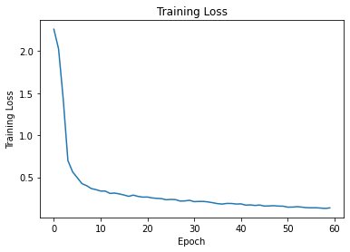

```python
# Plot the training loss
plt.plot(train_loss_values)
plt.xlabel("Epoch")
plt.ylabel("Training Loss")
plt.title("Training Loss")
plt.show()
```

## Testing your model

Using the previously created `DataLoader` for the test set, compute the percentage of correct predictions using the highest probability prediction.

If your accuracy is over 90%, great work, but see if you can push a bit further! If your accuracy is under 90%, you'll need to make improvements. Go back and check your model architecture, loss function, and optimizer to make sure they're appropriate for an image classification task.

```python
correct_predictions = 0
total_predictions = 0

# Set the model to evaluation mode
model.eval()

# Iterate over the test set
for images, labels in test_loader:
    # Move the data to the appropriate device
    images = images.to(device)
    labels = labels.to(device)

    # Forward pass
    outputs = model(images)

    # Get the predicted class labels
    _, predicted = torch.max(outputs.data, 1)

    # Update the count of correct predictions
    correct_predictions += (predicted == labels).sum().item()

    # Update the total number of predictions
    total_predictions += labels.size(0)

# Calculate the percentage of correct predictions
accuracy = (correct_predictions / total_predictions) * 100

print(f"Accuracy: {accuracy:.2f}%")
```

```
Accuracy: 95.88%
```

## Improving your model

Once your model is done training, try tweaking your hyperparameters and training again below to improve your accuracy on the test set!

```python
learning_rate = 0.001  # Adjust the learning rate
num_epochs = 30  # Increase or decrease the number of epochs
batch_size = 64  # Adjust the batch size
num_workers = 4  # Set the number of data loading subprocesses

# Define your model architecture
model = NeuralNetwork()
# Move the model to the appropriate device
model.to(device)

# Define your loss function
criterion = nn.CrossEntropyLoss()  # Try different loss functions

# Define your optimizer
optimizer = torch.optim.Adam(model.parameters(), lr=learning_rate)  # Adjust the optimizer and learning rate

# Create the data loaders
train_loader = DataLoader(train_set, batch_size=batch_size, shuffle=True, num_workers=num_workers, pin_memory=True)
test_loader = DataLoader(test_set, batch_size=batch_size, shuffle=False, num_workers=num_workers, pin_memory=True)

# Training loop
for epoch in range(num_epochs):
    running_loss = 0.0

    for batch_idx, (images, labels) in enumerate(train_loader):
        # Move the data to the appropriate device
        images = images.to(device)
        labels = labels.to(device)

        # Zero the gradients
        optimizer.zero_grad()

        # Forward pass
        outputs = model(images)
        loss = criterion(outputs, labels)

        # Backward pass and optimization
        loss.backward()
        optimizer.step()

        # Record the loss
        running_loss += loss.item()

        # Print the loss every few batches
        if (batch_idx + 1) % print_loss_every == 0:
            avg_loss = running_loss / print_loss_every
            print(f"Epoch [{epoch+1}/{num_epochs}], Batch [{batch_idx+1}/{len(train_loader)}], Loss: {avg_loss:.4f}")
            train_loss_values.append(avg_loss)
            running_loss = 0.0

    # Evaluate the model on the validation set
    model.eval()
    with torch.no_grad():
        correct_predictions = 0
        total_predictions = 0
        for images, labels in test_loader:
            images = images.to(device)
            labels = labels.to(device)

            outputs = model(images)
            _, predicted = torch.max(outputs.data, 1)

            correct_predictions += (predicted == labels).sum().item()
            total_predictions += labels.size(0)

        accuracy = (correct_predictions / total_predictions) * 100
        print(f"Epoch [{epoch+1}/{num_epochs}], Validation Accuracy: {accuracy:.2f}%")
    model.train()

# Calculate the final accuracy on the test set
model.eval()
with torch.no_grad():
    correct_predictions = 0
    total_predictions = 0
    for images, labels in test_loader:
        images = images.to(device)
        labels = labels.to(device)

        outputs = model(images)
        _, predicted = torch.max(outputs.data, 1)

        correct_predictions += (predicted == labels).sum().item()
        total_predictions += labels.size(0)

    accuracy = (correct_predictions / total_predictions) * 100
    print(f"Final Test Accuracy: {accuracy:.2f}%")
```

```
Epoch [1/30], Batch [250/938], Loss: 0.6449
Epoch [1/30], Batch [500/938], Loss: 0.2753
Epoch [1/30], Batch [750/938], Loss: 0.2232
Epoch [1/30], Validation Accuracy: 94.97%
Epoch [2/30], Batch [250/938], Loss: 0.1572
Epoch [2/30], Batch [500/938], Loss: 0.1444
Epoch [2/30], Batch [750/938], Loss: 0.1368
Epoch [2/30], Validation Accuracy: 95.93%
Epoch [3/30], Batch [250/938], Loss: 0.1000
Epoch [3/30], Batch [500/938], Loss: 0.1010
Epoch [3/30], Batch [750/938], Loss: 0.0971
Epoch [3/30], Validation Accuracy: 96.80%
Epoch [4/30], Batch [250/938], Loss: 0.0714
Epoch [4/30], Batch [500/938], Loss: 0.0696
Epoch [4/30], Batch [750/938], Loss: 0.0802
Epoch [4/30], Validation Accuracy: 97.34%
Epoch [5/30], Batch [250/938], Loss: 0.0582
Epoch [5/30], Batch [500/938], Loss: 0.0547
Epoch [5/30], Batch [750/938], Loss: 0.0587
Epoch [5/30], Validation Accuracy: 97.71%
Epoch [6/30], Batch [250/938], Loss: 0.0450
Epoch [6/30], Batch [500/938], Loss: 0.0483
Epoch [6/30], Batch [750/938], Loss: 0.0460
Epoch [6/30], Validation Accuracy: 97.57%
Epoch [7/30], Batch [250/938], Loss: 0.0340
Epoch [7/30], Batch [500/938], Loss: 0.0374
Epoch [7/30], Batch [750/938], Loss: 0.0375
Epoch [7/30], Validation Accuracy: 97.85%
Epoch [8/30], Batch [250/938], Loss: 0.0273
Epoch [8/30], Batch [500/938], Loss: 0.0317
Epoch [8/30], Batch [750/938], Loss: 0.0347
Epoch [8/30], Validation Accuracy: 97.82%
Epoch [9/30], Batch [250/938], Loss: 0.0221
Epoch [9/30], Batch [500/938], Loss: 0.0259
Epoch [9/30], Batch [750/938], Loss: 0.0272
Epoch [9/30], Validation Accuracy: 97.72%
Epoch [10/30], Batch [250/938], Loss: 0.0175
Epoch [10/30], Batch [500/938], Loss: 0.0211
Epoch [10/30], Batch [750/938], Loss: 0.0217
Epoch [10/30], Validation Accuracy: 97.63%
```

[output cut: 66 more lines]

```
Epoch [27/30], Batch [750/938], Loss: 0.0024
Epoch [27/30], Validation Accuracy: 97.76%
Epoch [28/30], Batch [250/938], Loss: 0.0085
Epoch [28/30], Batch [500/938], Loss: 0.0068
Epoch [28/30], Batch [750/938], Loss: 0.0091
Epoch [28/30], Validation Accuracy: 97.98%
Epoch [29/30], Batch [250/938], Loss: 0.0060
Epoch [29/30], Batch [500/938], Loss: 0.0057
Epoch [29/30], Batch [750/938], Loss: 0.0096
Epoch [29/30], Validation Accuracy: 97.74%
Epoch [30/30], Batch [250/938], Loss: 0.0073
Epoch [30/30], Batch [500/938], Loss: 0.0066
Epoch [30/30], Batch [750/938], Loss: 0.0054
Epoch [30/30], Validation Accuracy: 97.86%
Final Test Accuracy: 97.86%
```

## Saving your model

Using `torch.save`, save your model for future loading.

```python
import os

# Get the path of your code file
code_file_path = os.path.abspath("MNIST_Handwritten_Digits-STARTER.ipynb")

# Get the directory path of your code file
code_directory = os.path.dirname(code_file_path)

# Define the file path for saving the model
model_path = os.path.join(code_directory, 'model.pth')

# Save the model
torch.save(model.state_dict(), model_path)
```